# Drosophila melanogaster pupae TFL: summary of progress and future plans

Benjamin Walsh

31 May 2018

This document is a summary of the experimental work I have completed as of 31 May 2018, including a brief description of the methodology used, plots of the data collected, and future directions in which the work could be taken.

The experiment was designed to examine the Thermal Fertility Limits (TFL) of Drosophila melanogaster, when exposed to a heat shock during the pupal stage.

# 1. Methods

We subjected *Drosophila melanogaster* pupae to a 48 hour heat-shock at static temperatures ranging from 28°C to 35°C. Individuals that had pupated within 8 hours of each other were transferred to 96 well PCR plates (around 4-8 pupae per well), and subjected to one of 8 temperatures. For temperatures below 34°C, gradients creating distinct temperatures at specific locations across plates were used (gradient 1: 28,30,32.5°C; gradient 2:29,31,33.5°C).In each of these plates, intermediate temperatures were not used, giving 3 distinct temperatures in each case. For temperatures 34°C and 35°C, full static temperature plates were used in order to maximise sample size due to low survival. Plates were covered with standard PCR plate seals, with holes pierced in each well to allow for gaseous exchange. After 48 hours at their respective temperatures, the pupae were transferred to vials according to the PCR column they were treated in, placed back at 25°C and left to emerge.

Vials were checked 3 times per day, and both males and females were separated at emergence and kept at 25°C. Thereafter, the project was split into two distinct experiments.

### Male fertility

Males were kept for 3 days until sexual maturity, and subsequently placed with 2 females for 24 hours to allow males to mate. After this, males were discarded and females given 3 days to lay eggs. After laying, females were discarded and the vials were monitored for the presence of larvae (0/1), and the number of emerging adults in each vial was counted.

### Female fertility

Females were given 5 days to reach sexual maturity, and then given 2 males for 24 hours to allow females an opportunity to mate. After this, males were discaded and females given 3 opportunities to lay, each 48 hours to allow for accurate egg counts. This gave 3 egg counts, larval scores, and adult counts per laying attempt. It should be noted here that female survival was also monitored at each stage of this process, giving 6 survival data points per individual.

# 2. Results

Emergence of individuals from the treatments is shown below (Fig. 1). There was a relatively high emergence from 28°C to 32.5°C, and after this emergence drops significantly to 0 at 35°C. Due to the difficulty of identifying the sex of an individual at the pupal stage, this data cannot be split into male/ female emergence.

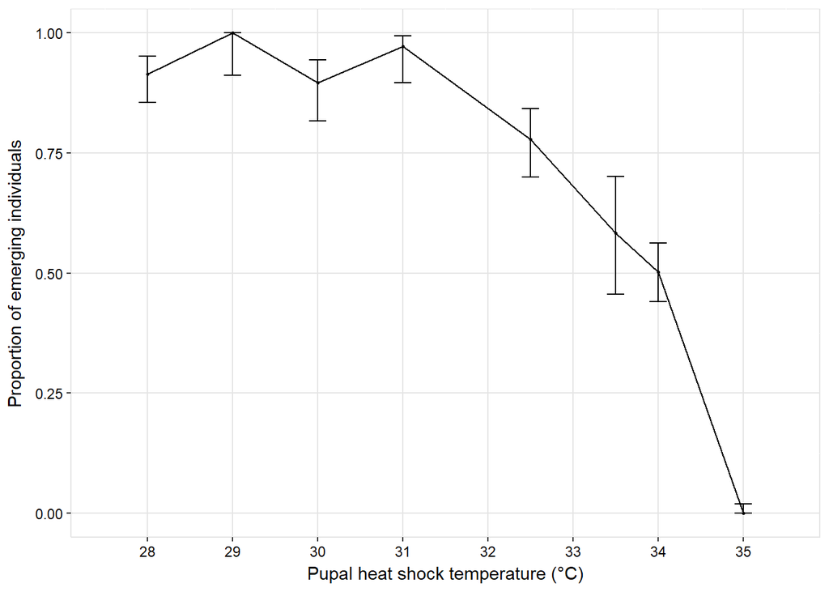

**Figure 1** The probability of emergence of *D. melanogaster* individuals exposed to a 48 hour heat shock at the pupal stage. Error bars represent 95% confidence intervals.

### Male fertility

Male fertility followed a similar trend to emergence with a relatively steep decline after a high plateau, however this decline occurs at much lower temperatures when examining fertilty as a binary trait. Figure 2 shows the proportion of fertile male *D. melanogaster* individuals over the range of pupal heat-shock temperatures. This indicates that a male’s fertility is almost fully compromised at 32.5°C, a temperature with around 75% emergence.

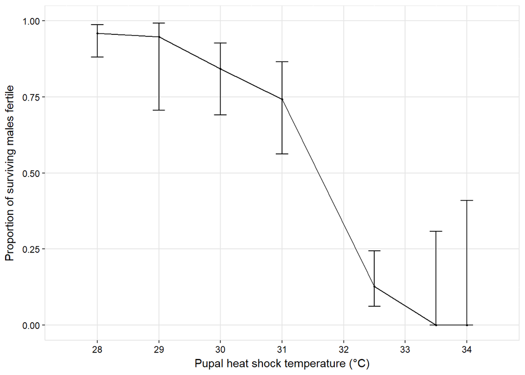

**Figure 2** The proportion of fertile male *D. melanogaster* individuals that have been exposed to a 48 hour heat shock at the pupal stage. Error bars represent 95% confidence intervals.

Figure 3 combines the two above graphs to show this difference in these two traits. There is around a 2°C difference in where these two traits are below 20%. This gap between fertility and mortality is important, and suggests that using mortality limits may underestimate the impact of pupal temperature on individuals in this species.

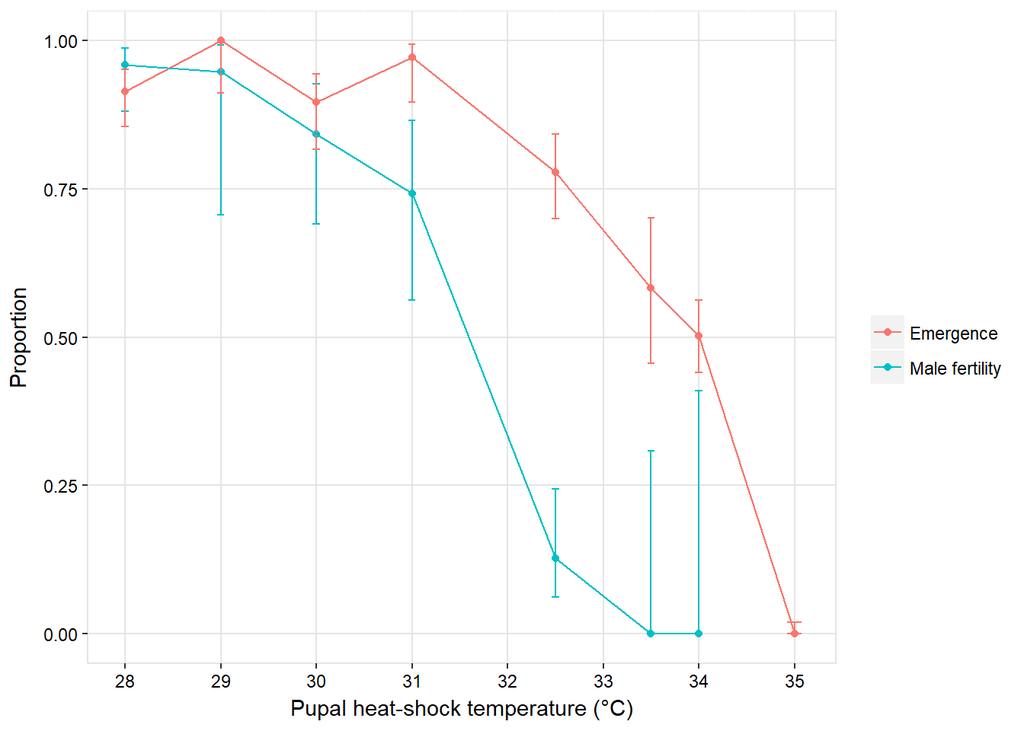

**Figure 3** The proportion of two traits of *D. melanogaster* that have been exposed to a 48 hour heat shock during the pupal stage. The red line represents the proportion of flies that emerge, and the green line represents the fertility of emerging **males**.

### Female fertility

The data for female fertility from the larval measure is much less clear, partly due to the fact that I have had to tinker with the methods to get the experiment to work properly and as such the data is not as robust. However, it appears that there is a slight impairment of fertility as temperature increases, as shown in the graph below.

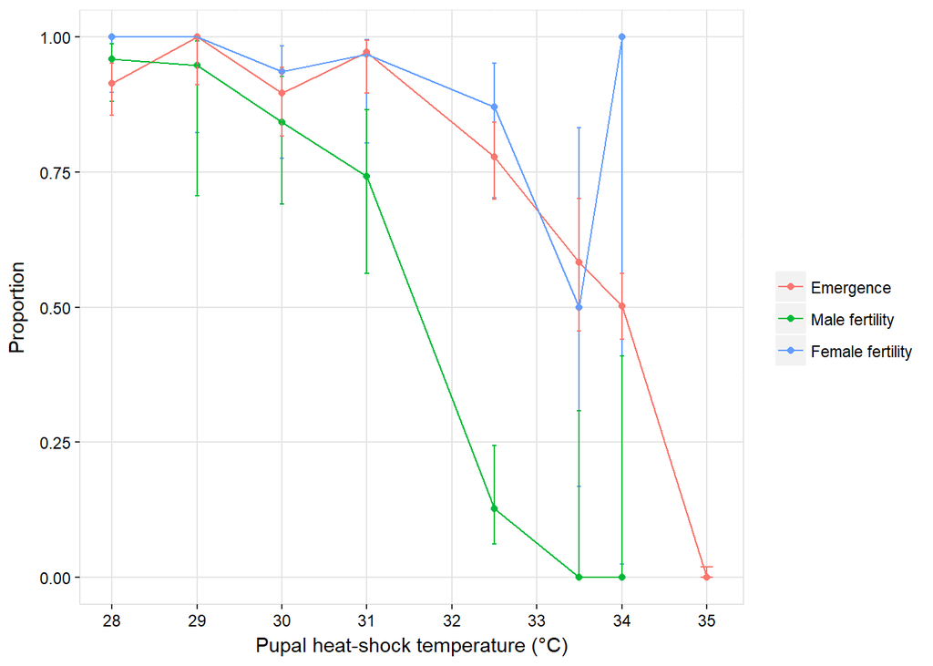

### Female survival

Of the flies that have successfully emerged, it appears that the majority of individuals, regardless of treatment, can survive to sexual maturity (which we have allocated as 5 days in *D. melanogaster*). After mating, the females are given 48 hours to lay 3 separate times. This gave us 6 data points for survival per individual, which allowed me to examine survival of females throughout the experiment. Figure 5 shows that immediately after mating and during the first laying period (between days 6 and 8), a significant proportion of females exposed to higher pupal temperatures die, suggesting that there could be an extreme cost of mating when an indvidual is already heat-stressed from an earlier life-history stage.

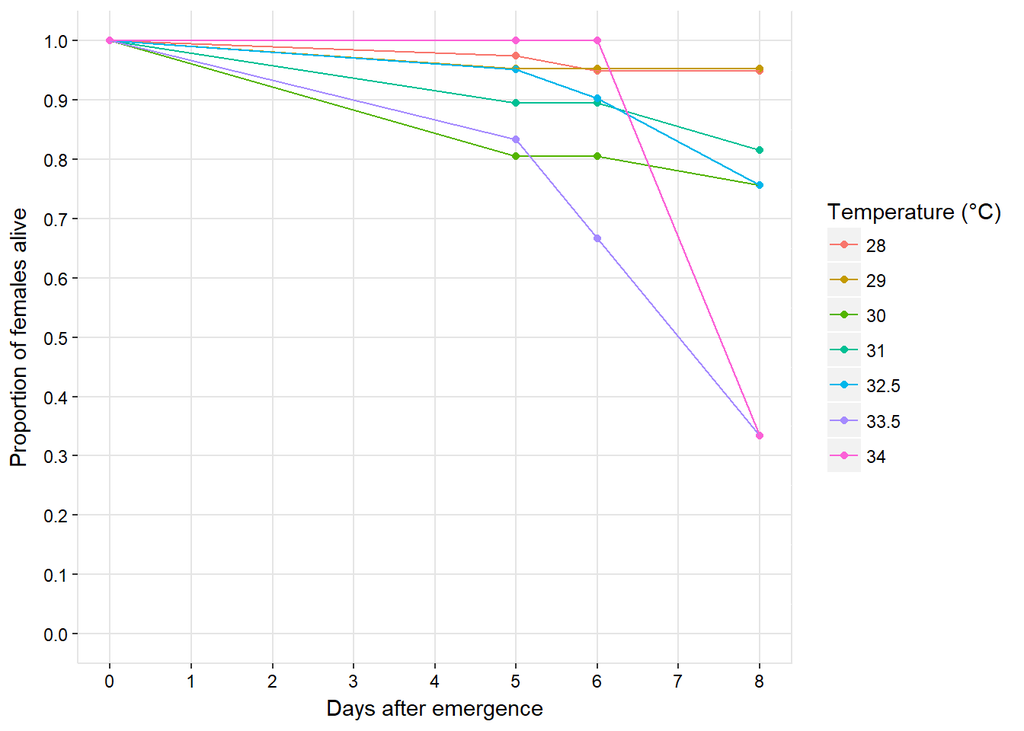

**Figure 5** Percentage survival of female *D. melanogaster* individuals that have been exposed to a heat shock at the pupal stage. Females were mated between days 5 and 6.

# 3. Following D. melanogaster experiments

### Experiment 2: Mating behaviour & sperm motility

*i). Behaviour* Simply a mating assay: do the flies mate? All of the usual traits will be measured (success, latency, duration).

*ii). Sperm motility* The technique that the French group (led by Jean David, Dominique Joly) used was to dissect the male’s seminal vesicle and assess whether there is *any* sign of motility (as a 1/0 binary trait). I have been able to confidently do this in the lab on benign individuals, seeing motility on all males examined so far. Thus, any noticible lack of motility should be a useful indicator of sperm viability as a qualitative trait. This is an easy trait to measure, however if motility is not shown to be a truly binary trait (which is likely), then there may be problems with this technique. David et al do not attempt to quantify any quantitative differences in sperm motility-it may be useful to attempt to design a qualitative or quantitative scale for motility if this technique (1/0) is not useful.

# 4. Future multi-species experiments

The most obvious major experiment to attempt when I have examined *D. melanogaster* in some depth is to take this method and apply it to a large number of species that spans the phylogenetic range of Drosophilidae, in order to examine whether these traits are variable and/or phylogenetically constrained, as well as to examine whether they correlate with species distributions or any other aspects of their biology/ecology.

Problems with applying this method to different species will be many, especially as I am treating them at a particular stage of development. Most obviously, the different species develop and mature at different rates, so the time between heat-shock and assessing fertility will vary from species to species.

*Species we currently have in the lab*

| Melanogaster | Obscura | Virilis | Repleta |
| --- | --- | --- | --- |
| D. melanogaster | D. subobscura | D. virilis | D. repleta |
| D. simulans (Madeira) | D. pseudoobascura | D. novamexicana | D. hydei |
| D. suzukii | D. bifasciatus | D. flavomontana | D. mercatorum |
| D. ananassae | D. maderensis |  |  |